# Customer Churn Prediction — Logistic Regression

# 6 Step 5 — Normalisation (Ensuring Convergence)

Normalisation is one of the most frequently skipped steps by beginners — and one of the most consequential.

## 6.1 Why Normalisation Is Essential for Logistic Regression

R’s `glm()` fits logistic regression using **Iteratively Reweighted Least Squares (IRLS)**, an iterative algorithm that takes gradient steps — small coefficient updates at each iteration — guided by the curvature of the log-likelihood surface.

**The problem:** If `income` ranges from 0 to 1,600 and a binary flag sits at 0 or 1, the gradient updates for each feature operate on completely different scales. The optimiser either takes infinitesimally small steps for large-scale features (very slow convergence) or overshoots for small-scale features (oscillation or outright failure to converge).

**The solution — z-score standardisation:**

$$z = \frac{x - \mu_{\text{train}}}{\sigma_{\text{train}}}$$

After scaling every feature has mean = 0 and standard deviation = 1. The optimiser works in a uniform space and converges reliably.

**Critical rule — no data leakage:**  
The scaler must be *fitted on training data only*, then *applied* to both sets. If you fit on the full dataset (including the test set), test-set information bleeds into the training process — a mistake called data leakage that artificially inflates evaluation metrics.

## 6.2 5a — Train / Test Split First

```r
# ── Prepare the modelling dataset ─────────────────────────────────────────────
# Select only the retained features plus the target variable.

model_df <- df %>%
  select(all_of(c(selected_features, "churn")))

# ── Stratified 80 / 20 split ──────────────────────────────────────────────────
# "Stratified" means the churn proportion is preserved in BOTH the training
# and test sets. Without stratification, the test set might — by random chance
# — contain very few churners, making evaluation unreliable.
#
# set.seed(42) ensures reproducibility: every run of this notebook produces
# exactly the same training and test rows.

set.seed(42)

train_idx <- createDataPartition(
  model_df$churn,
  p     = 0.80,    # 80% goes to training
  list  = FALSE,
  times = 1
)

train_df <- model_df[ train_idx, ]   # rows IN the partition -> training set
test_df  <- model_df[-train_idx, ]   # rows NOT in partition -> test set

cat("-----------------------------------\n")
cat(" TRAIN / TEST SPLIT\n")
```

```
 TRAIN / TEST SPLIT
```

```r
cat("-----------------------------------\n")
cat(sprintf("  Training samples : %d (%.0f%%)\n",
            nrow(train_df), 100 * nrow(train_df) / nrow(model_df)))
```

```
  Training samples : 161 (80%)
```

```r
cat(sprintf("  Test samples     : %d (%.0f%%)\n",
            nrow(test_df),  100 * nrow(test_df)  / nrow(model_df)))
```

```
  Test samples     : 39 (20%)
```

```r
cat(sprintf("\n  Churn rate — train : %s\n",
            percent(mean(train_df$churn == "Yes"), accuracy = 0.1)))
```

```
  Churn rate — train : 29.2%
```

```r
cat(sprintf("  Churn rate — test  : %s  (should be close to train if stratified)\n",
            percent(mean(test_df$churn  == "Yes"), accuracy = 0.1)))
```

```
  Churn rate — test  : 28.2%  (should be close to train if stratified)
```

## 6.3 5b — Fit the Scaler and Apply

```r
# ── Step 1: Fit preProcess parameters on the TRAINING SET ONLY ────────────────
# "center" = subtract the training mean from each feature column.
# "scale"  = divide by the training standard deviation.
# Together these implement z-score standardisation.
#
# The target variable (churn) must be excluded — it must not be transformed.

preproc <- preProcess(
  train_df %>% select(-churn),
  method = c("center", "scale")
)

# ── Step 2: Apply the SAME parameters to both sets ────────────────────────────
# predict() here does not make predictions — it applies the fitted transformation.
# This naming follows the standard caret interface for preProcess objects.

train_scaled <- predict(preproc, train_df)
test_scaled  <- predict(preproc, test_df)

# ── Step 3: Verify the scaling worked ─────────────────────────────────────────
means_after <- train_scaled %>% select(-churn) %>% summarise(across(everything(), mean))
sds_after   <- train_scaled %>% select(-churn) %>% summarise(across(everything(), sd))

cat("Post-scaling verification (training set):\n")
```

```
Post-scaling verification (training set):
```

```r
cat(sprintf("  Grand mean of all feature means : %.8f  (target: 0)\n",
            mean(unlist(means_after))))
```

```
  Grand mean of all feature means : -0.00000000  (target: 0)
```

```r
cat(sprintf("  Grand mean of all feature SDs   : %.8f  (target: 1)\n",
            mean(unlist(sds_after))))
```

```
  Grand mean of all feature SDs   : 1.00000000  (target: 1)
```

```r
cat("\nScaling confirmed. The optimiser will now work in a uniform space.\n")
```

```
Scaling confirmed. The optimiser will now work in a uniform space.
```

## 6.4 5c — Visualise the Effect of Scaling

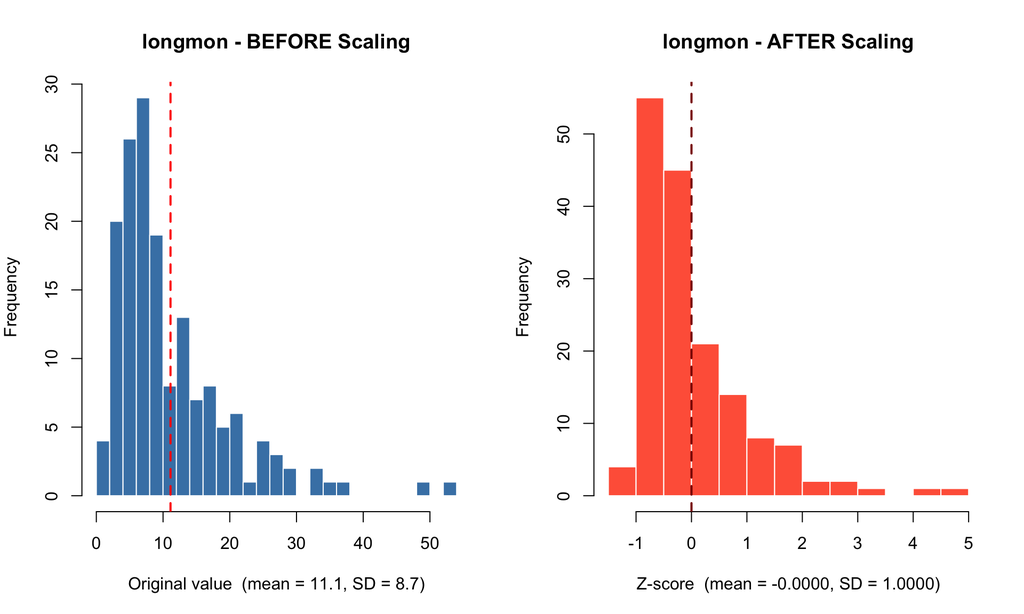

```r
# Side-by-side histograms for 'longmon' before and after scaling.
#
# The key teaching point: the SHAPE of the distribution is identical in both
# panels. Only the axis units change — from raw minutes to standard deviations
# from the mean. Scaling re-expresses data in a common unit; it does not distort
# relationships or alter the relative ordering of observations.

feat <- "longmon"

before_vals <- train_df[[feat]]
after_vals  <- train_scaled[[feat]]

par(mfrow = c(1, 2), mar = c(5, 4, 4, 2))

hist(before_vals,
     main   = paste(feat, "- BEFORE Scaling"),
     xlab   = sprintf("Original value  (mean = %.1f, SD = %.1f)",
                      mean(before_vals), sd(before_vals)),
     col    = "steelblue",
     border = "white",
     breaks = 20)
abline(v = mean(before_vals), col = "red", lwd = 2, lty = 2)

hist(after_vals,
     main   = paste(feat, "- AFTER Scaling"),
     xlab   = sprintf("Z-score  (mean = %.4f, SD = %.4f)",
                      mean(after_vals), sd(after_vals)),
     col    = "tomato",
     border = "white",
     breaks = 20)
abline(v = 0, col = "darkred", lwd = 2, lty = 2)
```

```r
par(mfrow = c(1, 1))
```

# 7 Step 6 — Train the Logistic Regression Model

Once the data is correctly prepared, the modelling step itself is concise. The hard work was in Steps 3 through 5.

## 7.1 How glm() Fits Logistic Regression

| Argument | Meaning |
| --- | --- |
| `churn ~ .` | Predict `churn` using all remaining columns as predictors |
| `family = binomial` | The outcome is binary — use the binomial family |
| `link = "logit"` | Apply the log-odds link function — the standard for binary outcomes |

Internally, R uses IRLS: it repeatedly adjusts coefficients to maximise the log-likelihood of observing the training labels given the current parameter estimates. Convergence is reached when the change in log-likelihood between iterations falls below a small tolerance.

```r
# ── Fit the logistic regression model ─────────────────────────────────────────
model <- glm(
  churn ~ .,
  data   = train_scaled,
  family = binomial(link = "logit")
)

cat("Model trained successfully.\n\n")
```

```
Model trained successfully.
```

```r
cat("What this model learns:\n")
```

```
What this model learns:
```

```r
cat("  logit(P(churn = Yes)) = b0 + b1*x1 + b2*x2 + ... + bk*xk\n\n")
```

```
  logit(P(churn = Yes)) = b0 + b1*x1 + b2*x2 + ... + bk*xk
```

```r
cat("  where logit(p) = log(p / (1-p))  -- the log of the odds ratio\n")
```

```
  where logit(p) = log(p / (1-p))  -- the log of the odds ratio
```

```r
cat("  To recover a probability: P = 1 / (1 + exp(-linear predictor))\n")
```

```
  To recover a probability: P = 1 / (1 + exp(-linear predictor))
```

## 7.2 6b — Raw Model Summary

```r
# Reading the glm() summary output:
#
#   Estimate   : beta coefficient in LOG-ODDS units.
#                Positive  => feature increases the odds of churn.
#                Negative  => feature decreases the odds of churn.
#
#   Std. Error : uncertainty around the estimate.
#                A large standard error signals low confidence in that coefficient.
#
#   z value    : Estimate / Std. Error (Wald test statistic).
#                A large absolute z value means the coefficient is far from zero.
#
#   Pr(>|z|)   : p-value for the Wald test.
#                < 0.05  (*)   significant at the 5% level
#                < 0.01  (**)  significant at the 1% level
#                < 0.001 (***) significant at the 0.1% level

summary(model)
```

```
Call:
glm(formula = churn ~ ., family = binomial(link = "logit"), data = train_scaled)

Coefficients:
             Estimate Std. Error z value Pr(>|z|)
(Intercept) -1.481183   0.281372  -5.264 1.41e-07 ***
tenure      -1.025454   0.530934  -1.931   0.0534 .
employ      -0.471722   0.377430  -1.250   0.2114
callcard    -0.935115   0.394062  -2.373   0.0176 *
longten      1.204696   1.375199   0.876   0.3810
longmon     -0.650251   1.209261  -0.538   0.5908
age         -0.361140   0.408115  -0.885   0.3762
equip        0.491349   0.725955   0.677   0.4985
address      0.342190   0.403754   0.848   0.3967
equipmon    -0.157958   0.793123  -0.199   0.8421
internet     0.001752   0.302308   0.006   0.9954
ebill        0.304131   0.272921   1.114   0.2651
cardten     -0.630997   0.903174  -0.699   0.4848
ed           0.095874   0.287365   0.334   0.7387
wiremon      0.465465   0.501066   0.929   0.3529
cardmon      0.794448   0.831342   0.956   0.3393
wireless    -0.141104   0.440220  -0.321   0.7486
voice        0.085707   0.329375   0.260   0.7947
pager        0.374712   0.341393   1.098   0.2724
---
Signif. codes:  0 '***' 0.001 '**' 0.01 '*' 0.05 '.' 0.1 ' ' 1

(Dispersion parameter for binomial family taken to be 1)

    Null deviance: 194.45  on 160  degrees of freedom
Residual deviance: 134.83  on 142  degrees of freedom
AIC: 172.83

Number of Fisher Scoring iterations: 6
```

## 7.3 6c — Odds Ratio Interpretation

```r
# Log-odds coefficients are mathematically convenient but hard to interpret
# intuitively. Exponentiating them gives ODDS RATIOS, which are much easier
# to communicate:
#
#   OR > 1  =>  feature INCREASES churn odds
#   OR < 1  =>  feature DECREASES churn odds
#   OR = 1  =>  feature has no effect on churn odds
#
# Example: OR = 1.50 for 'longmon' means a 1-SD increase in long-distance
# minutes is associated with 50% higher odds of churning, all else held constant.

coef_table <- tidy(model, conf.int = TRUE) %>%
  filter(term != "(Intercept)") %>%
  mutate(
    OddsRatio  = round(exp(estimate), 3),
    OR_CI_Low  = round(exp(conf.low),  3),
    OR_CI_High = round(exp(conf.high), 3),
    p.value    = round(p.value, 4),
    Significant = case_when(
      p.value < 0.001 ~ "***",
      p.value < 0.01  ~ "** ",
      p.value < 0.05  ~ "*  ",
      TRUE            ~ "   "
    ),
    Effect = ifelse(OddsRatio > 1, "Increases churn odds", "Decreases churn odds")
  ) %>%
  select(term, OddsRatio, OR_CI_Low, OR_CI_High, p.value, Significant, Effect) %>%
  arrange(desc(OddsRatio))

coef_table %>%
  kable(caption = "Odds Ratios — Effect of each feature on churn odds (per 1 SD change)") %>%
  kable_styling(bootstrap_options = c("striped", "hover"), full_width = FALSE) %>%
  column_spec(7, bold = TRUE,
              color = ifelse(coef_table$Effect == "Increases churn odds",
                             "tomato", "steelblue"))
```

Odds Ratios — Effect of each feature on churn odds (per 1 SD change)

term

OddsRatio

OR_CI_Low

OR_CI_High

p.value

Significant

Effect

longten

3.336

0.202

50.936

0.3810

Increases churn odds

cardmon

2.213

0.442

11.683

0.3393

Increases churn odds

equip

1.635

0.386

6.836

0.4985

Increases churn odds

wiremon

1.593

0.592

4.445

0.3529

Increases churn odds

pager

1.455

0.746

2.888

0.2724

Increases churn odds

address

1.408

0.639

3.166

0.3967

Increases churn odds

ebill

1.355

0.794

2.336

0.2651

Increases churn odds

ed

1.101

0.624

1.945

0.7387

Increases churn odds

voice

1.089

0.557

2.061

0.7947

Increases churn odds

internet

1.002

0.549

1.814

0.9954

Increases churn odds

wireless

0.868

0.358

2.053

0.7486

Decreases churn odds

equipmon

0.854

0.180

4.204

0.8421

Decreases churn odds

age

0.697

0.302

1.523

0.3762

Decreases churn odds

employ

0.624

0.288

1.294

0.2114

Decreases churn odds

cardten

0.532

0.083

3.030

0.4848

Decreases churn odds

longmon

0.522

0.046

5.736

0.5908

Decreases churn odds

callcard

0.393

0.173

0.822

0.0176

Decreases churn odds

tenure

0.359

0.124

1.021

0.0534

Decreases churn odds

## 7.4 6d — Coefficient Forest Plot

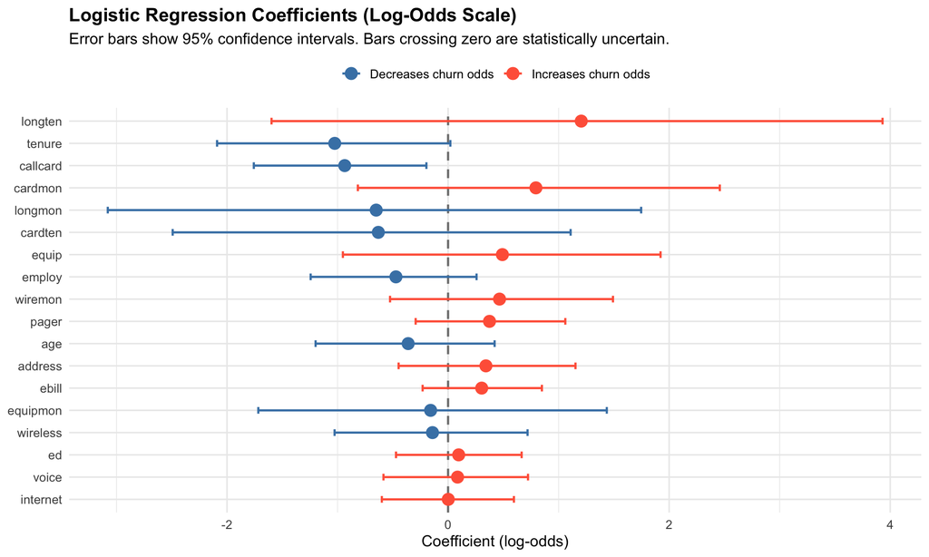

```r
# A forest plot shows each coefficient in log-odds space with its 95%
# confidence interval bar.
#
# If a confidence interval bar CROSSES ZERO, the effect may not be
# statistically reliable. Zero in log-odds corresponds to an odds ratio
# of 1, meaning no effect on churn odds.

coef_df <- tidy(model, conf.int = TRUE) %>%
  filter(term != "(Intercept)") %>%
  arrange(desc(abs(estimate)))

ggplot(coef_df, aes(x = estimate,
                     y = reorder(term, abs(estimate)),
                     colour = estimate > 0)) +
  geom_vline(xintercept = 0, colour = "grey50", linetype = "dashed", linewidth = 0.8) +
  geom_errorbarh(aes(xmin = conf.low, xmax = conf.high),
                 height = 0.3, linewidth = 0.8) +
  geom_point(size = 4) +
  scale_colour_manual(
    values = c("FALSE" = "steelblue", "TRUE" = "tomato"),
    labels = c("FALSE" = "Decreases churn odds", "TRUE" = "Increases churn odds")
  ) +
  labs(
    title    = "Logistic Regression Coefficients (Log-Odds Scale)",
    subtitle = "Error bars show 95% confidence intervals. Bars crossing zero are statistically uncertain.",
    x        = "Coefficient (log-odds)",
    y        = NULL,
    colour   = NULL
  ) +
  theme_minimal(base_size = 12) +
  theme(legend.position = "top", plot.title = element_text(face = "bold"))
```

# 8 Step 7 — Model Evaluation

Accuracy alone is a poor metric for imbalanced classification. We use several complementary measures to build a complete picture of model quality.

## 8.1 7a — The Loss Function: Log-Loss (Binary Cross-Entropy)

The **loss function** is the quantity logistic regression *minimises* during training. For binary classification this is **log-loss**, also called binary cross-entropy:

$$\mathcal{L} = -\frac{1}{n} \sum_{i=1}^{n} \Bigl[ y_i \cdot \log(\hat{p}_i) + (1 - y_i) \cdot \log(1 - \hat{p}_i) \Bigr]$$

**Intuition:** log-loss heavily penalises *confident wrong predictions*. If the model assigns P(churn) = 0.99 to a customer who did not churn, that single observation contributes a large penalty. The model therefore learns to be well-calibrated — not merely directionally correct, but appropriately uncertain when the signal is weak.

| Log-Loss value | Interpretation |
| --- | --- |
| Close to 0 | Nearly perfect model |
| 0.693 (ln 2) | Random classifier — coin-flip baseline |
| Greater than 0.693 | Worse than random guessing |

```r
# ── Obtain predicted probabilities ────────────────────────────────────────────
# type = "response" returns P(churn = "Yes") in [0, 1].
# type = "link" would return raw log-odds — not what metric functions expect.

train_prob <- predict(model, newdata = train_scaled, type = "response")
test_prob  <- predict(model, newdata = test_scaled,  type = "response")

# Convert factor labels to 0 / 1 numeric for the metric functions
y_train_num <- as.numeric(train_scaled$churn) - 1   # "Yes" -> 1, "No" -> 0
y_test_num  <- as.numeric(test_scaled$churn)  - 1

# ── Compute Log-Loss ──────────────────────────────────────────────────────────
# MLmetrics::LogLoss(y_pred, y_true)  -- predictions first, true labels second
train_logloss <- LogLoss(train_prob, y_train_num)
test_logloss  <- LogLoss(test_prob,  y_test_num)

cat("-------------------------------------------\n")
cat(" LOSS FUNCTION — Binary Cross-Entropy\n")
```

```
 LOSS FUNCTION — Binary Cross-Entropy
```

```r
cat("-------------------------------------------\n")
cat(sprintf("  Training log-loss       : %.4f\n", train_logloss))
```

```
  Training log-loss       : 0.4187
```

```r
cat(sprintf("  Test log-loss           : %.4f\n", test_logloss))
```

```
  Test log-loss           : 0.4745
```

```r
cat(sprintf("  Random baseline (ln 2)  : 0.6931\n"))
```

```
  Random baseline (ln 2)  : 0.6931
```

```r
cat(sprintf("  Improvement vs baseline : %.1f%%\n\n",
            100 * (0.6931 - test_logloss) / 0.6931))
```

```
  Improvement vs baseline : 31.5%
```

```r
# Overfitting diagnostic
gap <- test_logloss - train_logloss
cat(sprintf("  Train-test gap          : %.4f", gap))
```

```
  Train-test gap          : 0.0558
```

```r
if (gap > 0.05) {
  cat("  — possible overfitting: test loss is notably higher than train\n")
} else {
  cat("  — model generalises well: train and test loss are close\n")
}
```

```
  — possible overfitting: test loss is notably higher than train
```

```r
cat("\n")
```

```r
if      (test_logloss < 0.40) {
  cat("  Rating: Excellent — substantially better than random\n")
} else if (test_logloss < 0.55) {
  cat("  Rating: Good — meaningfully better than random\n")
} else if (test_logloss < 0.65) {
  cat("  Rating: Modest — only slightly better than random\n")
} else {
  cat("  Rating: Poor — near random; revisit feature selection\n")
}
```

```
  Rating: Good — meaningfully better than random
```

## 8.2 7b — AUC-ROC: Ranking Quality

```r
# The ROC (Receiver Operating Characteristic) curve plots the True Positive Rate
# (Sensitivity) against the False Positive Rate at every possible probability
# threshold from 0 to 1.
#
# AUC = Area Under the ROC Curve
#   AUC = 1.0  =>  perfect — every churner is ranked above every non-churner
#   AUC = 0.5  =>  random — no discrimination ability at all
#   AUC < 0.5  =>  worse than random (the model's ranking is effectively inverted)
#
# Key property: AUC is threshold-independent. It measures how well the model
# RANKS customers by churn risk, regardless of where you set the decision cutoff.
# This makes AUC robust and meaningful on imbalanced datasets.

roc_obj <- roc(
  response  = test_scaled$churn,
  predictor = test_prob,
  levels    = c("No", "Yes"),
  direction = "<"   # higher probability corresponds to the positive class ("Yes")
)

auc_val <- auc(roc_obj)

cat(sprintf("AUC-ROC: %.4f\n\n", auc_val))
```

```
AUC-ROC: 0.8149
```

```r
cat(sprintf("Interpretation: the model correctly ranks a randomly chosen churner\n"))
```

```
Interpretation: the model correctly ranks a randomly chosen churner
```

```r
cat(sprintf("above a randomly chosen non-churner %.1f%% of the time.\n", auc_val * 100))
```

```
above a randomly chosen non-churner 81.5% of the time.
```

[figure not shown]

```r
# ── Plot the ROC curve ─────────────────────────────────────────────────────────
plot(
  roc_obj,
  col  = "tomato",
  lwd  = 2.5,
  main = sprintf("ROC Curve — Churn Prediction  |  AUC = %.4f", auc_val),
  xlab = "False Positive Rate (1 - Specificity)",
  ylab = "True Positive Rate (Sensitivity / Recall)"
)
# Diagonal line = random classifier baseline (AUC = 0.5)
abline(a = 0, b = 1, lty = 2, col = "grey60", lwd = 1.5)

legend(
  "bottomright",
  legend = c(sprintf("Logistic Regression (AUC = %.3f)", auc_val),
             "Random Classifier  (AUC = 0.500)"),
  col    = c("tomato", "grey60"),
  lwd    = c(2.5, 1.5),
  lty    = c(1, 2),
  bty    = "n"
)

# Shade the area under the curve for visual emphasis
polygon(
  c(roc_obj$specificities, 0),
  c(roc_obj$sensitivities, 0),
  col    = adjustcolor("tomato", alpha.f = 0.12),
  border = NA
)
```

## 8.3 7c — Confusion Matrix and Classification Metrics

```r
# ── Convert probabilities to class labels ─────────────────────────────────────
# At threshold = 0.5: if P(churn) > 0.5 predict "Yes", otherwise predict "No".
#
# 0.5 is the default threshold, not necessarily the optimal one. In practice
# you might lower it (e.g. to 0.3) to catch more actual churners at the cost
# of more false alarms. This is a business decision, not a model decision.

test_pred <- ifelse(test_prob > 0.5, "Yes", "No") %>%
  factor(levels = c("No", "Yes"))

# ── Confusion Matrix ───────────────────────────────────────────────────────────
# The four cells:
#
#   True Positive  (TP): predicted "Yes", actual "Yes"  — correctly caught churner
#   True Negative  (TN): predicted "No",  actual "No"   — correctly retained customer
#   False Positive (FP): predicted "Yes", actual "No"   — unnecessary intervention
#   False Negative (FN): predicted "No",  actual "Yes"  — missed churner (often costly)
#
# positive = "Yes" tells caret which class is the event of interest, so that
# Sensitivity, Precision, and Recall are all computed with respect to churn.

cm <- confusionMatrix(
  data      = test_pred,
  reference = test_scaled$churn,
  positive  = "Yes"
)

print(cm)
```

```
Confusion Matrix and Statistics

          Reference
Prediction No Yes
       No  24   7
       Yes  4   4

               Accuracy : 0.7179
                 95% CI : (0.5513, 0.85)
    No Information Rate : 0.7179
    P-Value [Acc > NIR] : 0.5804

                  Kappa : 0.2407

 Mcnemar's Test P-Value : 0.5465

            Sensitivity : 0.3636
            Specificity : 0.8571
         Pos Pred Value : 0.5000
         Neg Pred Value : 0.7742
             Prevalence : 0.2821
         Detection Rate : 0.1026
   Detection Prevalence : 0.2051
      Balanced Accuracy : 0.6104

       'Positive' Class : Yes
```

## 8.4 7d — Confusion Matrix Heatmap

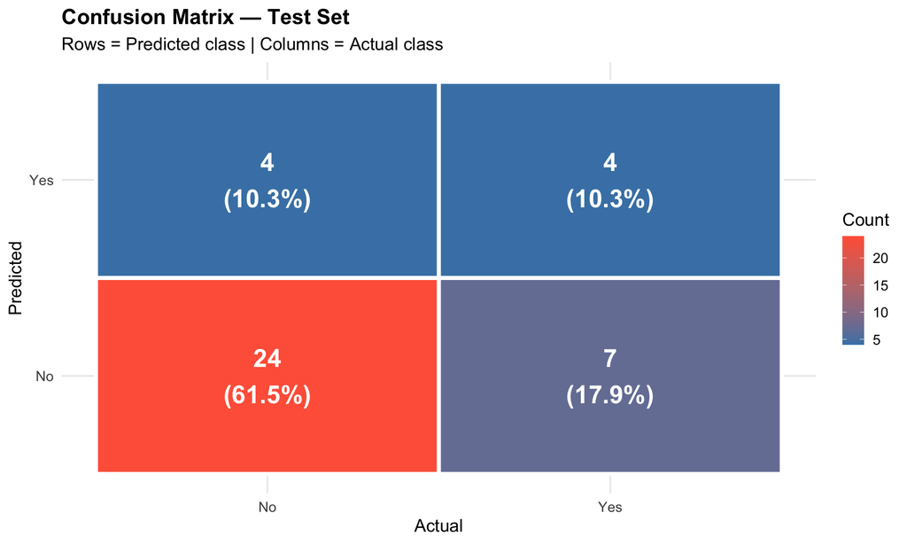

```r
# A heatmap version of the confusion matrix is easier to scan at a glance
# than a raw numeric table.

cm_table       <- as.data.frame(cm$table)
names(cm_table) <- c("Predicted", "Actual", "Count")

total          <- sum(cm_table$Count)
cm_table$Pct   <- percent(cm_table$Count / total, accuracy = 0.1)
cm_table$Label <- paste0(cm_table$Count, "\n(", cm_table$Pct, ")")

ggplot(cm_table, aes(x = Actual, y = Predicted, fill = Count)) +
  geom_tile(colour = "white", linewidth = 1.5) +
  geom_text(aes(label = Label), size = 7, fontface = "bold", colour = "white") +
  scale_fill_gradient(low = "steelblue", high = "tomato") +
  labs(
    title    = "Confusion Matrix — Test Set",
    subtitle = "Rows = Predicted class | Columns = Actual class",
    fill     = "Count"
  ) +
  theme_minimal(base_size = 14) +
  theme(plot.title = element_text(face = "bold"))
```

## 8.5 7e — Complete Metrics Summary

```r
# Collect all key metrics from the confusionMatrix object into one summary table.
# Each metric answers a different question about model quality.

accuracy    <- cm$overall["Accuracy"]
precision   <- cm$byClass["Precision"]    # of all predicted churners, how many actually churned?
recall      <- cm$byClass["Recall"]       # of all actual churners, how many did we catch?
f1          <- cm$byClass["F1"]           # harmonic mean of precision and recall
specificity <- cm$byClass["Specificity"]  # of all actual non-churners, how many correctly labelled?

metrics_table <- tibble(
  Metric = c(
    "Accuracy",
    "Precision",
    "Recall (Sensitivity)",
    "Specificity",
    "F1-Score",
    "Log-Loss",
    "AUC-ROC"
  ),
  Value = c(
    percent(accuracy,    accuracy = 0.1),
    percent(precision,   accuracy = 0.1),
    percent(recall,      accuracy = 0.1),
    percent(specificity, accuracy = 0.1),
    round(f1,           4),
    round(test_logloss, 4),
    round(auc_val,      4)
  ),
  Interpretation = c(
    "Percentage of all predictions that are correct",
    "Of all predicted churners, how many actually churned?",
    "Of all actual churners, what fraction did we catch?",
    "Of all actual non-churners, what fraction did we correctly identify?",
    "Harmonic mean of Precision and Recall — 1.0 is perfect",
    "Lower is better | 0.6931 = coin-flip baseline",
    "Higher is better | 0.5 = coin-flip | 1.0 = perfect"
  )
)

metrics_table %>%
  kable(caption = "Complete Model Evaluation — Test Set") %>%
  kable_styling(bootstrap_options = c("striped", "hover"), full_width = FALSE) %>%
  row_spec(5:7, bold = TRUE, background = "#f0f4f8")
```

Complete Model Evaluation — Test Set

| Metric | Value | Interpretation |
| --- | --- | --- |
| Accuracy | 71.8% | Percentage of all predictions that are correct |
| Precision | 50.0% | Of all predicted churners, how many actually churned? |
| Recall (Sensitivity) | 36.4% | Of all actual churners, what fraction did we catch? |
| Specificity | 85.7% | Of all actual non-churners, what fraction did we correctly identify? |
| F1-Score | 0.4211 | Harmonic mean of Precision and Recall — 1.0 is perfect |
| Log-Loss | 0.4745 | Lower is better &#124; 0.6931 = coin-flip baseline |
| AUC-ROC | 0.8149 | Higher is better &#124; 0.5 = coin-flip &#124; 1.0 = perfect |

**Which metric matters most in a churn problem?**  
Recall (catching actual churners) is typically more important than Precision. A missed churner represents permanently lost revenue; a false alarm costs one retention call. The business context determines which metric to prioritise, and the optimal threshold can be shifted on the ROC curve to reflect that priority.

# 9 Step 8 — Final Summary

```r
cat("======================================================\n")
cat("  CHURN PREDICTION MODEL — COMPLETE SUMMARY\n")
```

```
  CHURN PREDICTION MODEL — COMPLETE SUMMARY
```

```r
cat("======================================================\n\n")
cat("  DATA\n")
```

```
  DATA
```

```r
cat(sprintf("  |- Dataset          : %d customers, %d total columns\n", nrow(df), ncol(df)))
```

```
  |- Dataset          : 200 customers, 28 total columns
```

```r
cat(sprintf("  |- Features used    : %d (after correlation filtering)\n", length(selected_features)))
```

```
  |- Features used    : 18 (after correlation filtering)
```

```r
cat(sprintf("  '- Train/Test split : 80%%/20%% stratified (seed = 42)\n\n"))
```

```
  '- Train/Test split : 80%/20% stratified (seed = 42)
```

```r
cat("  PREPROCESSING\n")
```

```
  PREPROCESSING
```

```r
cat("  |- Response variable cast to factor (required for glm binomial)\n")
```

```
  |- Response variable cast to factor (required for glm binomial)
```

```r
cat("  |- Features filtered: |Pearson r| > 0.10 with churn\n")
```

```
  |- Features filtered: |Pearson r| > 0.10 with churn
```

```r
cat("  |- Log-transform duplicates removed: loglong, lninc\n")
```

```
  |- Log-transform duplicates removed: loglong, lninc
```

```r
cat("  '- StandardScaler applied (center + scale, fitted on train only)\n\n")
```

```
  '- StandardScaler applied (center + scale, fitted on train only)
```

```r
cat("  MODEL\n")
```

```
  MODEL
```

```r
cat("  '- glm(family = binomial(link = 'logit')) — Logistic Regression\n\n")
```

```
  '- glm(family = binomial(link = 'logit')) — Logistic Regression
```

```r
cat("  PERFORMANCE — TEST SET\n")
```

```
  PERFORMANCE — TEST SET
```

```r
cat(sprintf("  |- Accuracy    : %s\n",  percent(accuracy,    accuracy = 0.1)))
```

```
  |- Accuracy    : 71.8%
```

```r
cat(sprintf("  |- Precision   : %s\n",  percent(precision,   accuracy = 0.1)))
```

```
  |- Precision   : 50.0%
```

```r
cat(sprintf("  |- Recall      : %s\n",  percent(recall,      accuracy = 0.1)))
```

```
  |- Recall      : 36.4%
```

```r
cat(sprintf("  |- Specificity : %s\n",  percent(specificity, accuracy = 0.1)))
```

```
  |- Specificity : 85.7%
```

```r
cat(sprintf("  |- F1-Score    : %.4f\n",  f1))
```

```
  |- F1-Score    : 0.4211
```

```r
cat(sprintf("  |- Log-Loss    : %.4f  (random baseline: 0.6931)\n", test_logloss))
```

```
  |- Log-Loss    : 0.4745  (random baseline: 0.6931)
```

```r
cat(sprintf("  '- AUC-ROC     : %.4f  (random baseline: 0.5000)\n", auc_val))
```

```
  '- AUC-ROC     : 0.8149  (random baseline: 0.5000)
```

```r
cat("======================================================\n")
```

# 10 Concepts Recap

| Concept | R Tool | Why It Matters |
| --- | --- | --- |
| Binary categorical outcome | `factor(churn, levels = c(0,1))` | Required for `glm()` to apply logistic, not linear, regression |
| Sigmoid function | Built into `glm(family = binomial)` | Maps the linear predictor to a valid probability in (0, 1) |
| Feature selection | Pearson correlation, threshold `\|r\| > 0.10` | Removes noise and controls multicollinearity |
| Multicollinearity check | `corrplot()` heatmap | Identifies redundant predictors to remove |
| z-score normalisation | `caret::preProcess("center", "scale")` | Ensures the IRLS optimiser converges reliably |
| No data leakage | Scaler fitted on training set only | Prevents inflated test-set performance metrics |
| Log-Loss | `MLmetrics::LogLoss()` | The actual loss function — penalises confident wrong predictions |
| AUC-ROC | `pROC::roc()` and `auc()` | Threshold-independent ranking quality — robust to class imbalance |
| Confusion Matrix | `caret::confusionMatrix()` | Exposes TP / TN / FP / FN and all derived classification metrics |
| Odds Ratios | `exp(coef(model))` | Converts log-odds coefficients into interpretable effect sizes |

# 11 Suggested Next Steps

**1. Handle class imbalance with class weights**

```r
# Penalise missing a churner more heavily than a false alarm.
model_weighted <- glm(
  churn ~ .,
  data    = train_scaled,
  family  = binomial,
  weights = ifelse(train_scaled$churn == "Yes", 3, 1)
)
```

**2. Optimise the classification threshold**

```r
# The default 0.5 threshold is rarely optimal.
# Sweep across candidate thresholds and select the one that maximises
# the metric most relevant to the business (e.g. Recall or F1-Score).
thresholds <- seq(0.1, 0.9, by = 0.05)
```

**3. Regularised logistic regression (LASSO / Ridge)**

```r
library(glmnet)
# L1 penalty (LASSO) automatically shrinks unimportant coefficients to zero,
# providing built-in feature selection and reducing the risk of overfitting.
```

**4. Stepwise feature selection guided by AIC**

```r
# AIC balances model fit against complexity.
# step() adds or removes predictors greedily to minimise AIC.
model_step <- step(model, direction = "both")
```

**5. Compare against non-linear models**

```r
library(randomForest)
library(xgboost)
# Tree-based ensemble methods capture non-linear relationships and feature
# interactions that logistic regression cannot express. Comparing results
# tells you whether the linear assumptions are adequate for this dataset.
```

*End of notebook. You now have a rigorous, fully documented foundation in logistic regression — covering data preparation, feature selection, normalisation, model training, loss-function evaluation, and coefficient interpretation. Every concept here transfers directly to any binary classification problem.*